# Problem Set 2

Author

Lauren Nagle

Published

today

**GitHub repo:** https://github.com/laurengnagle/ec422_ps2_Nagle

## Data

The data are seasonally adjusted monthly unemployment rates for the United States, Oregon, California, Texas, and New York, pulled from FRED (Federal Reserve Bank of St. Louis) using the tidyquant package. The sample runs from January 1976 to the most recent available month.

```r
unemp_raw <- read_rds("data/unemp_raw.rds")
head(unemp_raw)
```

```
# A tibble: 6 × 3
  symbol date       price
  <chr>  <date>     <dbl>
1 UNRATE 1976-01-01   7.9
2 UNRATE 1976-02-01   7.7
3 UNRATE 1976-03-01   7.6
4 UNRATE 1976-04-01   7.7
5 UNRATE 1976-05-01   7.4
6 UNRATE 1976-06-01   7.6
```

## Wrangling

**Table 1: Unemployment rate summary, full sample (1976–present)**

```r
kable(unemp_summary, digits = 2,
      col.names = c("Region", "Mean (%)", "Min (%)", "Max (%)"))
```

| Region | Mean (%) | Min (%) | Max (%) |
| --- | --- | --- | --- |
| California | 7.07 | 3.8 | 16.1 |
| New York | 6.35 | 3.8 | 16.7 |
| Oregon | 6.66 | 3.4 | 13.7 |
| Texas | 5.85 | 3.4 | 12.8 |
| United States | 6.05 | 3.4 | 14.8 |

**Table 2: Unemployment rate summary, January 2015–present**

```r
kable(unemp_recent_summary, digits = 2,
      col.names = c("Region", "Mean (%)", "Min (%)", "Max (%)"))
```

| Region | Mean (%) | Min (%) | Max (%) |
| --- | --- | --- | --- |
| California | 5.63 | 3.8 | 16.1 |
| New York | 5.10 | 3.8 | 16.7 |
| Oregon | 4.75 | 3.4 | 13.7 |
| Texas | 4.58 | 3.4 | 12.8 |
| United States | 4.62 | 3.4 | 14.8 |

**Table 3: Five largest month-over-month increases, excluding 2020** (ties included)

```r
kable(unemp_top_increases_no_covid, digits = 2)
```

| symbol | date | unemployment_rate | region | unemployment_rate_change |
| --- | --- | --- | --- | --- |
| TXUR | 2009-05-01 | 7.6 | Texas | 1.1 |
| ORUR | 2008-12-01 | 8.9 | Oregon | 0.7 |
| ORUR | 2008-11-01 | 8.2 | Oregon | 0.7 |
| ORUR | 2009-01-01 | 9.6 | Oregon | 0.7 |
| ORUR | 1980-03-01 | 7.4 | Oregon | 0.6 |
| UNRATE | 1980-04-01 | 6.9 | United States | 0.6 |

**Table 4: Five largest month-over-month decreases, excluding 2020** (ties included)

```r
kable(unemp_top_decreases_no_covid, digits = 2)
```

| symbol | date | unemployment_rate | region | unemployment_rate_change |
| --- | --- | --- | --- | --- |
| UNRATE | 1983-07-01 | 9.4 | United States | -0.7 |
| NYUR | 2021-09-01 | 6.2 | New York | -0.6 |
| ORUR | 1977-05-01 | 7.8 | Oregon | -0.5 |
| CAUR | 2021-07-01 | 7.4 | California | -0.5 |
| CAUR | 2021-09-01 | 6.5 | California | -0.5 |
| NYUR | 2021-07-01 | 7.0 | New York | -0.5 |
| UNRATE | 2010-12-01 | 9.3 | United States | -0.5 |
| UNRATE | 2014-04-01 | 6.2 | United States | -0.5 |
| UNRATE | 2021-07-01 | 5.4 | United States | -0.5 |

## Visualization

**Figure 1** shows all five unemployment rates on one plot.

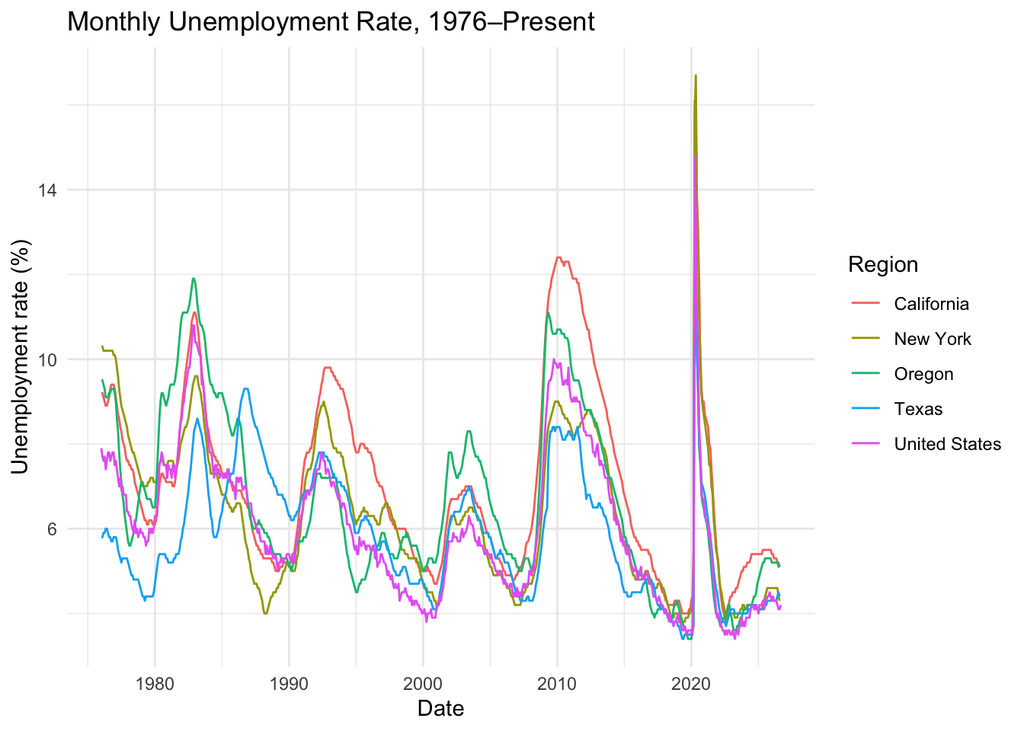

```r
ggplot(unemp, aes(x = date, y = unemployment_rate, color = region)) +
  geom_line() +
  labs(title = "Monthly Unemployment Rate, 1976–Present",
       x = "Date", y = "Unemployment rate (%)", color = "Region") +
  theme_minimal()
```

**Figure 2** shows each region in its own panel.

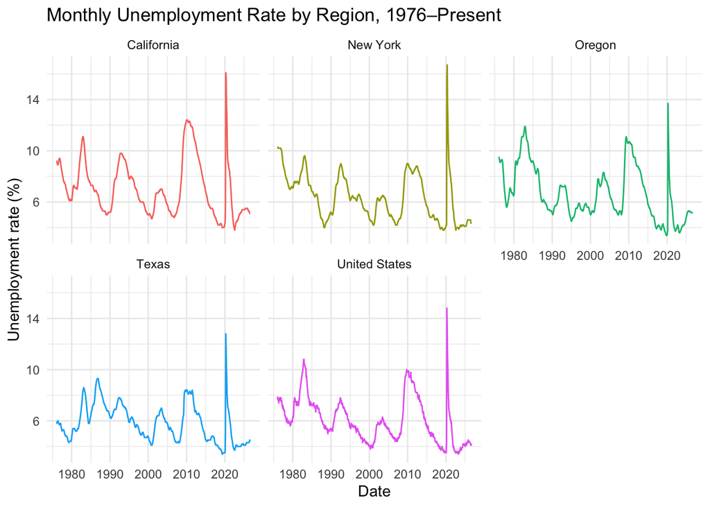

```r
ggplot(unemp, aes(x = date, y = unemployment_rate, color = region)) +
  geom_line() +
  facet_wrap(~ region) +
  labs(title = "Monthly Unemployment Rate by Region, 1976–Present",
       x = "Date", y = "Unemployment rate (%)") +
  theme_minimal() +
  theme(legend.position = "none")
```

**Figure 3** shows the average unemployment rate by region over the full sample, ordered lowest to highest.

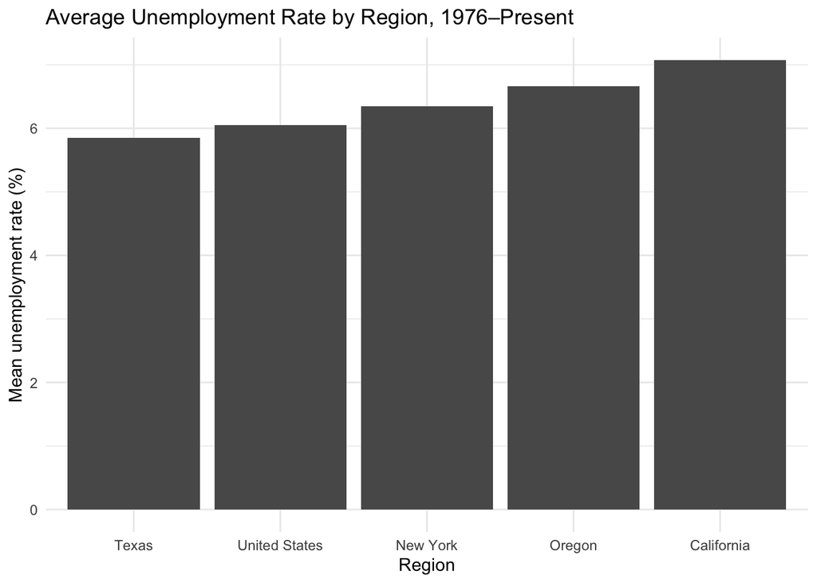

```r
ggplot(unemp_summary, aes(x = fct_reorder(region, mean_rate), y = mean_rate)) +
  geom_col() +
  labs(title = "Average Unemployment Rate by Region, 1976–Present",
       x = "Region", y = "Mean unemployment rate (%)") +
  theme_minimal()
```

**Figure 4**

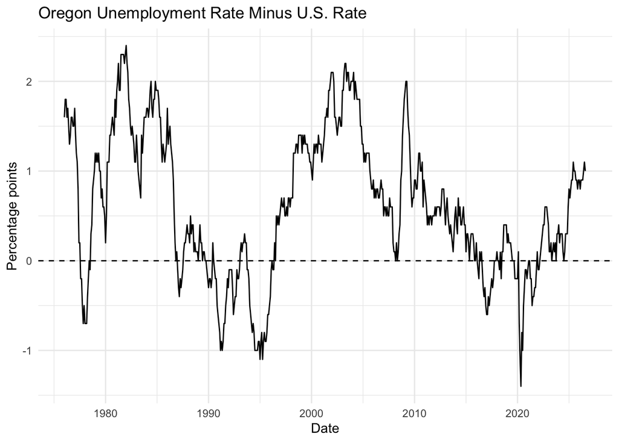

```r
ggplot(or_us_gap, aes(x = date, y = gap)) +
  geom_line() +
  geom_hline(yintercept = 0, linetype = "dashed") +
  labs(title = "Oregon Unemployment Rate Minus U.S. Rate",
       x = "Date", y = "Percentage points") +
  theme_minimal()
```

## Reflection

Once the data was loaded, everything else was pretty straightforward. What tripped me up the most was the setup, keeping track of which lines belong in the terminal or console, and connecting my local repository to GitHub. I initially opened the wrong repository before finding the correct ps2 one. I feel much more comfortable with the add, commit, and push workflow, and with using git log to confirm my work was saved.